# Chen-WomenBoardsDownsizing-2022-IJHRM.pdf

Converted from PDF `Chen-WomenBoardsDownsizing-2022-IJHRM.pdf` · 34 pages · anchors: page `#pN`, block `#pN-bK`

Page 1

#### Women on boards of directors and firm performance: the mediation of employment downsizing

Ming-Yuan Chen and Chun-Lin Kao

Graduate Institute of Human Resource Management, National Central University, Jhongli, Taoyuan, Taiwan

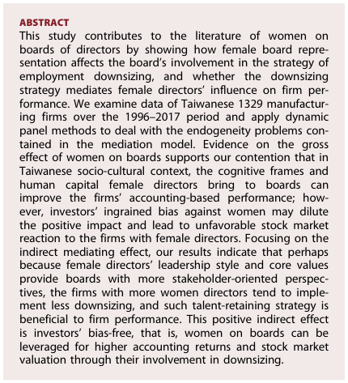

NOTE: figure/graphic rendered as an image from the PDF; its content is not machine-readable text. Caption (if any) follows as the next block.

**text found inside the figure**

ABSTRACT This study contributes to the literature of women on boards of directors by showing how female board representation affects the board’s involvement in the strategy of employment downsizing, and whether the downsizing strategy mediates female directors’ influence on firm performance. We examine data of Taiwanese 1329 manufacturing firms over the 1996–2017 period and apply dynamic panel methods to deal with the endogeneity problems contained in the mediation model. Evidence on the gross effect of women on boards supports our contention that in Taiwanese socio-cultural context, the cognitive frames and human capital female directors bring to boards can improve the firms’ accounting-based performance; however, investors’ ingrained bias against women may dilute the positive impact and lead to unfavorable stock market reaction to the firms with female directors. Focusing on the indirect mediating effect, our results indicate that perhaps because female directors’ leadership style and core values provide boards with more stakeholder-oriented perspectives, the firms with more women directors tend to implement less downsizing, and such talent-retaining strategy is beneficial to firm performance. This positive indirect effect is investors’ bias-free, that is, women on boards can be leveraged for higher accounting returns and stock market valuation through their involvement in downsizing.

KEYWORDS women on boards of directors; employment downsizing; firm performance; mediation; dynamic panel methods

1. Introduction

Gender diversity in the boardroom has received considerable academic and practical attention in recent years. Studies in management and finance mainly focus on whether board gender diversity, through increasing the presence of women on boards of directors, can improve firm performance. The discussion, rooted in the corporate governance theories,

CONTACT M.-Y. Chen mychen@mgt.ncu.edu.tw Graduate Institute of Human Resource Management, National Central University, No.300, Jhongda Rd, Jhongli, Taoyuan Taiwan. 32001, Tel.: þ886-3-422-7151 ext. 66153, Fax: þ886-3-422-7492

2020 Informa UK Limited, trading as Taylor & Francis Group

THE INTERNATIONAL JOURNAL OF HUMAN RESOURCE MANAGEMENT 2022, VOL. 33, NO. 13, 2597–2629 https://doi.org/10.1080/09585192.2020.1867617

Page 2

typically addresses the role of female directors in improving the supervisory and advisory functions of boards (Carter et al., 2010; Lucas-Perez et al., 2015). From an agency theory viewpoint, the board of directors serves as the representative for shareholders and is the primary monitoring and supervising mechanism to align the interests of managers with those of shareholders (Fama & Jensen, 1983; Jensen & Meckling, 1976). Achieving effective supervision depends largely on the independence of the board of directors. The literature suggests that the presence of women directors can lead to a more independent board, as they bring different cognitive capacity, core values, and human capital to the maledominated boards. Enhancing the effectiveness of the board definitely has a positive impact on firm performance.

In a similar vein, the resource dependence theory (Hillman et al., 2000; Hillman & Dalziel, 2003; Pfeffer & Salancik, 1978) suggests that board effectiveness is determined by the external resources that individual members are able to bring into the firm. Board directors can reduce firm uncertainty by connecting the firm to outside communities. Diversity in the boardroom is conducive to providing a variety of advice and counsel, increasing channels for communicating information between external organizations and the firm, and improving access to commitment or support from important elements outside the firm. The provision of these resources of dependence enhances board functioning and firm performance.

The evidence for the impact of board gender diversity on firm performance is not conclusive. Some studies have found a positive relationship between female board representation and firm performance, as measured by accounting-based performance or stock market returns (Carter et al., 2003; Christiansen et al., 2016; Erhardt et al., 2003; Krishnan & Park, 2005; L€uckerath-Rovers, 2013). However, others have found no statistically significant results (Carter et al., 2010; Farrell & Hersch, 2005; Francoeur et al., 2008; Rose, 2007; Wang, 2020) or revealed a negative relationship (Adams & Ferreira, 2009; Bøhren & Strøm, 2010; Mınguez-Vera & Martin, 2011).

Most of existent studies have directly estimated the relationship between women’s representation on boards and firm performance. They usually overlook what actions a board with women directors tends to make, and how such actions affect firm performance. The literature in strategic management and within the corporate governance framework emphasizes that business actions and their subsequent performance are, to a large extent, a function of corporate upper echelons (Hambrick, 2007; Hambrick & Mason, 1984). The inclusion of qualified women to an all-male board is likely to increase the board’s variety due to

2598 M.-Y. CHEN AND C.-L. KAO

Page 3

differences in values, personalities, experiences, and other human factors (Adams & Ferreira, 2009), which influences the decision-making process of the strategies and thus firm performance. As a result, analyzing the proximal factors that mediate the relationship between female board representation and firm performance can contribute to the understanding of board gender diversity (Johnson et al., 2013; Post & Byron, 2015; Pye & Pettigrew, 2005). Some studies make this effort and find that women directors influence firm performance through their more risk-averse decisions, higher levels of market orientation, and strategic involvement (Davis et al., 2010; Dezs€o & Ross, 2012; Khan & Vieito, 2013; Levi et al., 2014; Zhang & Qu, 2016). They suggest that women directors’ participation may result in boards becoming more involved in providing advice and shaping strategy, as boards are increasingly able to deal with the complexity and uncertainty surrounding business strategic decisions (Post & Byron, 2015).

From the strategic view of human resources, this study pinpoints a personnel strategy that mediates the relationship between women on boards of directors and firm performance, namely the strategy of employment downsizing. Downsizing is a frequently used business strategy for reducing costs or returning firms to short-term profits. Downsizing has complex consequences on human capital, human resource practices, and employee behaviors, which aggregate into numerous parts of the organization and has varied and profound impacts on the people of the organization (McMahan et al., 2012). It is a stressful, life-changing experience for everyone involved — the victims of downsizing, the survivors of downsizing, and the managers who undertake downsizing. Therefore, downsizing is probably one of the most important decisions for business managers. The strategic view usually states that because of large investment in employees through hiring and training processes, employees should be treated as assets to be nurtured rather than expenses to be minimized (De Meuse et al., 1994). Whether the personnel strategy is decided in terms of an asset-cultivating or costcutting perspective, and hence the decision of downsizing, may be related to gender differences in the preferences or values of business leaders. Previous studies have indicated that female leaders, more than their male peers, are more altruistic, value more self-transcendence, and have greater concern for the well- being of their employees, even at the expense of short-term profits (Adams & Funk, 2012). Female directors tend to emphasize the value of employees and question the cost reduction of downsizing, as downsizing may breach the psychological contract of workers, lower their morale, and lead to more recruitment and training costs when filling the vacancy in the future. We examine the

THE INTERNATIONAL JOURNAL OF HUMAN RESOURCE MANAGEMENT 2599

Page 4

mediating role of downsizing strategy to reveal how women on boards influence firm performance through their involvement in the human resource strategies.

This paper uses data of Taiwanese firms to test the relationship between women on boards, employment downsizing, and firm performance. A challenge for the Taiwan labor market, arising from the special Taiwan-China relation, makes downsizing a crucial mediating factor to be studied. Because of China’s rapid economic growth, Taiwan has been suffering from brain drain. The huge Chinese market has created more jobs and faster career development, attracting foreign talent and skilled workers to move to China. This flow of talent is large in Taiwan because people in Taiwan share common language, ethnic links, and cultural traits with Chinese. Many Taiwanese have strong affection and commitment for their original families in China. While downsizing may improve short-term profits, it will create the shortage of talent in the future as the downsized employees, especially skilled workers and professionals, have a great tendency of moving to China. Thus, it is imperative for Taiwanese firms to consider how to retain their employees and cope with rapid brain drain in the job market. The decision of downsizing matters for Taiwanese firms, with the importance no less than innovation activities or other corporate strategies. Considering downsizing as a mediating strategy in examining the impact of women on boards on firm performance manifests the role of women in deciding the strategy related to the survival and development of firms.

The sample of this study is all listed and OTC manufacturing firms on the Taiwan Stock Exchange (TWSE) in 2017. By reviewing their annual reports, we construct a panel data set of the proportion of female directors for all firms’ board elections held from 1996 to 2017. The panel data set is unbalanced because firms may have board elections taking place in various years. This sampling procedure differs from that of other studies applying panel data, as their observations are based on annual data so that the board composition tends to be the same for the years during the board term. By focusing on the time of board director elections, the relationships between changes in board gender diversity, downsizing strategy during each board term, and resulting performance can be more accurately estimated. From the perspective of econometric analysis, our mediation model has significant endogeneity problems. Although using panel data can control for the endogeneity arising from unobserved confounding factors, the model has two other sources of endogeneity: endogenous determination of downsizing, and potential reverse causality between women on boards and firm performance. We will use the dynamic probit model and dynamic panel regressions to mitigate endogeneity problems.

2600 M.-Y. CHEN AND C.-L. KAO

Page 5

The remainder of this paper is organized as follows. First, we describe the issues and hypotheses connecting women on boards, downsizing, and firm performance. Second, the econometric models, measurement of variables, and empirical results are presented. Third, we provide discussion and implications. Finally, we conclude the paper.

2. Issues and hypotheses

2.1. Women on boards and employment downsizing

The theory of upper echelons (Carpenter et al., 2004; Hambrick, 2007; Hambrick & Mason, 1984) states that top managers differ in the cognitive frames, which determine the interpretation that managers make about the situations they face, and consequently their choices and decisions. Managers’ cognitive frames are greatly influenced by their personal experiences, values, and personalities. This theory can serve as a framework for linking board diversity with board actions. Bertrand and Mullainathan (2003) indicate that business leaders have their own personal styles when investing, financing, and making other strategic decisions. They find that the estimated manager-specific effects on strategic decisions are associated with unobservable characteristics such as experiences and preferences. Gender differences may be an underlying source of such unobservable characteristics. The gender-related literature (Andreoni & Vesterlund, 2001; Babcock et al., 2017; Byrnes et al., 1999; Niederle & Vesterlund, 2007) has indicated that women tend to engage in more prosocial behavior, more altruism, more risk aversion, and shy away from competition. Women are less inclined to secure financial rewards than men, and are more patient in taking actions that give nonfinancial, delayed rewards, or low probability of promotion. Adams and Funk (2012) also suggest that female directors hold more self- transcendence value, like universalism and benevolence, but less self-enhancement value of achievement and authority, than male directors. The gender differences in these core values are not very different from culture to culture.

While traditional stereotypes link firm leadership to masculinity, some studies show that successful female leaders tend to adopt a transformational leadership style rather than a transactional leadership style that is purely male-specific leadership (Bass & Avolio, 1994;; Dezs€o & Ross, 2012). Transformed leaders build the consensus and commitment of employees to the organization’s goals through their influence and charisma, and based on that, leaders create favorable conditions for their followers to change belief and behavior, inspiring them to achieve high levels of performance. Through transformational leadership, women take

THE INTERNATIONAL JOURNAL OF HUMAN RESOURCE MANAGEMENT 2601

Page 6

into account the interests of others and build positive relationships with colleagues and employees. This means that female directors may lead their firms to take more stakeholder-oriented actions when there is tension between the interests of shareholders and those of other stakeholders, such as maintaining stable employment and wage levels during periods of declining demand (Adams et al., 2011).

There is evidence that women have a greater orientation towards employees, society and different stakeholders. Matsa and Miller (2013) look at the impact of Norway’s 2006 board gender quota system and find that companies affected by the system have a fairly different employment policy from those not affected by the system. Affected companies tend not to reduce their labor employment after the quota system. This may be due to changes in decision preferences and values resulting from changes in the gender structure in the leadership of the firms. The fewer downsizing practices reflect a longer-term and more stakeholderoriented policy under a gender-diversity quota system. Their another study (Matsa & Miller, 2014) also finds that female-dominated companies are more likely to engage in labor hoarding than male- dominated companies during the recession and are therefore less likely to lay off. More broadly, a number of studies have indicated that women on boards are more likely able to engage with multiple stakeholders (employees, customers, public communities, and environment) other than just shareholders, and respond to their needs, resulting in an avenue for demonstrating the firm’s achievement in corporate social responsibility (CSR) (for a review, see Byron & Post, 2016; Rao & Tilt, 2016).

Fewer downsizing activities and more stable employment arising from the employee (stakeholder) orientation of female directors exemplify that women on boards can bring greater effectiveness to the decision-making of the boards of directors. Based on the corporate governance theories, several studies have stated that female directors tend to bring a greater variety of perspectives, experiences and network ties, to show greater willingness to work together and collaborate on conflict resolution, and to encourage the decision-making considering the different interests of all stakeholders (Baixauli-Soler et al., 2016; Lucas-Perez et al., 2015). These traits provide the necessary independence to the board and improve board effectiveness through high audit quality and less vulnerability to group-think (Adams & Ferreira, 2009; Carter et al., 2003). In terms of downsizing, while organizations engaging in downsizing may have short-term gains by reducing labor costs, they may incur longerterm losses outweighing the initial gains. Hiring and training costs of employees are essentially sunk costs, so stable and long-term employment is the key to maximize the return of these costs (Oi, 1962; Parsons,

2602 M.-Y. CHEN AND C.-L. KAO

Page 7

1972). Besides, laying off well-trained and experienced employees implies that future recruitment and training may lead to higher opportunity costs that drag down firm productivity (Hamermesh & Pfann, 1996). Thus, even though it is costly in the short term, avoiding layoffs and hiring labors that are more than required for the production process reflect a more effective human resource practice that could result in long-term benefits for the firms. Less downsizing, because of the presence of women on boards, is a decision manifesting the effectiveness of boards.

In sum, current views point out that differences in core values, leadership styles, and interpersonal relationships that board directors generate because of gender differences may enhance board effectiveness and lead to longer-term, more employee-oriented personnel policies. We propose the following hypothesis.

Hypothesis 1: The firms having a greater proportion of women on the board of directors are less likely to engage in employment downsizing.

2.2. Employment downsizing and firm performance

Although a major benefit of downsizing is the purposed savings in labor costs by eliminating redundant employees and streamlining operations, in reality, the benefit is not so much because the financial enticements and severance packages given to downsized workers can reduce any labor savings (De Meuse & Dai, 2012), and because as noted in the previous section, longer- term losses may outweigh these savings. Indeed, numerous studies examining the impact of downsizing on organizations have found that downsizing does not have apparent effects on either increasing financial performance or halting the downward spiral of financial loss, and may even deteriorate firm performance (Cascio et al., 1997; Cascio & Young, 2003; De Meuse et al., 1994; Guthrie & Datta, 2008; Kawai, 2015; Lowe, 1998). Overall, downsizing firms do not outperform (even underperform) the non-downsizing firms in the year of layoffs, as well as the post-downsizing period. There is also evidence that the negative relationship between downsizing and firm performance is particularly significant for certain implementation means of downsizing (Luan et al., 2013; Mu~noz-Bullon & Sanchez-Bueno, 2010), and that investors may amplify negative response to downsizing in periods of industry downsizing waves, in the face of changes in macroeconomic conditions, and subsequent to declining firm performance (Brauer & Zimmermann, 2019).

Psychological contract theory (Morrison & Robinson, 1997; Rousseau, 1995) provides a theoretical explanation for the negative outcomes of downsizing. This theory emphasizes a mutual relationship based on trust

THE INTERNATIONAL JOURNAL OF HUMAN RESOURCE MANAGEMENT 2603

Page 8

and predictability between employees and employers. Downsizing is often perceived by employees as a breach of the psychological contract, which causes them to retract psychologically or physically and reduce their work engagement and organizational commitment. The negative impact of downsizing on performance may result from demotivated employees, increased voluntary separation, decreased job satisfaction, lower affective attachment to the organization, disrupted intraorganizational social networks, and the failure to retain critical skills, capabilities, experience, and knowledge (Amabile & Conti, 1999; Lopez Bohle et al., 2018; Mellahi & Wilkinson, 2010; Shah, 2000). Psychological contract theory implies that successful organizations are characterized by high employment security. A stable employment policy enables the development of employee–employer trust and enhances communication, cooperation, and organizational commitment. This is a primary human resource policy to increase the capacity of performance and innovation.

Although many management studies might adopt loosely specified empirical models, which ignore that downsizing is endogenously predicted by organizational or environmental factors (Datta et al., 2010), they typically discover that there appear more disadvantages than advantages to lay off large numbers of employees. Organizational distress caused by mass employee outflows may take several years to overcome. For Taiwanese firms, the adverse consequence of downsizing would be amplified. The above-mentioned tremendous talent flow from Taiwan to the Chinese market may reinforce the harmful effect of downsizing. The firms’ rapid downsizing without making an effort on the retention of employees will hasten the movement of downsized workforce to China. This threat on the labor market further worsens the performance of the firms because it becomes more difficult, and frequently at higher salaries, for firms to recruit new employees when there is recovery. Therefore, we have the following hypothesis.

Hypothesis 2: Employment downsizing has a negative effect on firm performance.

2.3. Women on boards, firm performance, and mediation of employment downsizing

As mentioned earlier, the literature concerning board gender diversity suggests that female directors can lead to a more effective board by introducing different perspectives and ruling out prejudices, obtaining diverse resources and external connections, and encouraging positive board behaviors such as philanthropy programs, better attendance and audit quality. We contend that such improvement in board effectiveness

2604 M.-Y. CHEN AND C.-L. KAO

Page 9

brought about by women on boards will be notable in the context of Taiwanese society. The stereotype of bias against women is still prevalent in Taiwan. Influenced by the traditional Confucianism, women have been considered more of a supportive role in many aspects due to the prejudice of their limited strength and intelligence. Women are being encouraged to support their spouse and family instead of pursuing their personal career achievement. Therefore, there are stronger cognitive and human capital varieties that separate male and female members of the corporate upper echelons in Taiwan, which may not present in many developed countries. The result is that the rarity of women participation in Taiwanese firms’ boards may make their cognitive contribution more potent to the performance improvement of the firms, once they have been recruited into the boards. We can hypothesize that women on boards tend to positively affect firm performance.

However, this prediction may be more relevant to accounting-based performance rather than market performance. Even though the genderbalance in the workplace has made gradual progress in the past several decades, most powerful women in Taiwan are empowered by their families, and to some extent the family name gains more trust from the investors, as they trust the men behind the name rather than the women in charge. To most of investors, women on boards are just a token of the family firms’ intention of showing their progress. Female directors perhaps really make the board more effective and conducive to firm performance, yet investors perceive that instead of having female directors, appointing the family men behind women to the board will generate higher firm value. Thus, when women starting to join the boardroom, the investors may react to this change negatively by reducing their shares of firms based on their subconscious bias against women. Accordingly, the effect of women on boards on stock market performance is likely to be attenuated or becomes negative because of investors’ bias and unfavorable reaction. Taking all these into account, the following hypothesis is formulated.

Hypothesis 3: Women on boards of directors have a positive effect on accountingbased performance, but have no or a negative effect on market performance.

This study aims to investigate the mediation of downsizing between women on boards and firm performance. Based on the discussion in the above sections, Figure 1 shows a graphic illustration (Greek letters are corresponding to the econometric models described in the next section). Previous studies usually estimate path 1 only (gross effect), without considering firm performance as a function of the board strategy (i.e. paths 2 and 3). We can combine the predicted negative effect of women on

THE INTERNATIONAL JOURNAL OF HUMAN RESOURCE MANAGEMENT 2605

Page 10

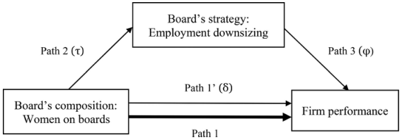

NOTE: figure/graphic rendered as an image from the PDF; its content is not machine-readable text. Caption (if any) follows as the next block.

boards on downsizing (path 2) and the predicted negative effect of downsizing on firm performance (path 3) to suggest that there is an positive indirect effect of female board representation on firm performance through downsizing. In other words, the firms with a higher proportion of women directors on the board are less likely to engage in downsizing, and then fewer layoffs, which imply a more stable employment policy for retaining talent, are beneficial to firm performance. More importantly, this is a real and investors’ bias-free channel through which women directors can exercise positive influence on firms, so this indirect effect will be reflected on both accounting-based performance and stock market performance. After partialling out the effect via downsizing, path 1<sup>0</sup> captures the remaining effect of women on boards on firm performance. We propose the last hypothesis.

Hypothesis 4: Women on boards of directors have a positive indirect effect, mediated by employment downsizing, on both accounting-based and market performance.

3. Econometric models and variable specifications

We firstly review the annual reports of all listed and OTC manufacturing firms on the TWSE in 2017 and calculate the proportion of female directors for their every election of board directors between 1996 and 2017. For firms beginning to appear on the TWSE after 1996, the reviewing period is from the year of their first appearance to 2017. In Taiwan, listed and OTC companies usually have a board re-election every three years, but sometimes more often when necessary. For example, Taiwan Semiconductor Manufacturing Company (TSMC), the world’s largest contract chipmaker, has held board elections in 1997, 2000, 2003, 2006, 2009, 2012, and 2015 during the sampling period. Next, for all elected boards, we record employment data to identify the downsizing strategy during the board term, collect financial data to calculate firm

Figure 1. Research Framework.

2606 M.-Y. CHEN AND C.-L. KAO

Page 11

performance for the board term, and organize data for the variables used in the empirical models. The detailed specification and measurement are described below. We finally have an unbalanced panel of 1329 firms in 22 industries with 7577 board elections.<sup>1</sup>

3.1. Econometric models

We start with a dynamic random-effects probit model to examine the effect of women on boards on the tendency of downsizing. The model can be written as

where subscript i indexes individual firms, and t indexes the t-th board election. t ¼ 2, … , Ni, with Ni representing the number of board elections for firm i during 1996–2017 (e.g. Ni ¼ 7 for TSMC). DSit is a binary variable for downsizing. DSit ¼ 1 indicating that the t-th elected board implements at least one cross-year layoff above a certain level of workforce reductions during its term. We do not take the change in employment as a continuous dependent variable, but use a discrete variable representing a specific threshold of employment change. A small change in the employment is part of the day-to-day work of the management, which is a matter that the board of directors generally does not engage in, and that women directors are particularly less likely to provide advice when management makes such decisions. However, a large scale of employment dismissal is a major personnel decision, so we can believe that female directors are the co-decision-makers and exercise their influence on such policy. Thus, a binary choice analysis would be a more appropriate approach. In the literature, researchers have typically chosen some thresholds of employment reductions to identify downsizing, such as 5% (Cascio et al., 1997; Guthrie & Datta, 2008; Vicente-Lorente & Suarez-Gonzalez, 2007), 10% (Ahmadjian & Robinson, 2001; Wagar, 2009;), and 20% (Luan et al., 2013; Yawson, 2006). Based on the consideration that boards make the decision on large-scale layoffs, we identify cross-year 10% reductions as downsizing, and 20% reductions for robustness check.

In Equation (1), the coefficient of DSit–1, c, represents the degree of state dependence. Mass layoffs are a crucial decision of the firm, so whether similar layoffs are carried out in the previous board term apparently affects the actions of the current board. FDIRit represents the proportion of female directors in the t-th board election. The vector Xit stands for other observed variables (discussed later) that are hypothesized to influence the downsizing decision, and are measured at the year-end before the t-th board term begins. Tt is a set of year dummies to filter

THE INTERNATIONAL JOURNAL OF HUMAN RESOURCE MANAGEMENT 2607

Page 12

Correlation between ui (time-invariant term) and DSit–1 makes the latter endogenous in Equation (1). Estimation requires an assumption about the relation between the first period observations (initial conditions), DSi1, and ui. We cannot assume that the initial conditions are exogenous (i.e. DSi1 and ui are uncorrelated) because the start of the process is not the start of the observation period for each firm. Heckman (1981) suggests an approximation to the process generating the first period observations using the same form of equation as for the rest of the observations but with some restrictions. Heckman’s approach has been used in the studies of intertemporal labor force participation (Hyslop, 1999; Stewart, 2007). We will provide Heckman estimation for Equation (1). As the lagged dependent variable is needed in the model estimation, the observations for estimating Equation (1) are 6248 for 1329 firms. To test the effect of female directorship on firm performance, in particular the indirect effect through its influence on the downsizing strategy, we specify a dynamic panel regression model as

where t ¼ 2, … , Ni. The dependent variable PFit is the average firm performance for the years of the t-th board term, measured as average return on assets (ROA) (accounting-based performance) and average Tobin’s q (market performance). Tobin’s q is measured as the sum of the market value of common equity, the market value of preferred stock, and the book value of total debt, divided by the book value of total assets. The explanatory variables include the average firm performance for the years of the previous board term (PFit–1), the proportion of female directors for the t-th board election (FDIRit), the decision of downsizing during the t-th board term (DSit) , and observed control variables that may cause heterogeneity in firm performance and are measured as the average values for the previous board term (Vit–1). Vit–1 can

2608 M.-Y. CHEN AND C.-L. KAO

Page 13

thus be assumed as exogenous variables in the model. Combing the coefficient on DSit in Equation (2) and the coefficient on FDIRit in in Equation (1), that is, u and s, we can identify how women on boards affect firm performance via their influence on downsizing. The coefficient d captures the effect of female directorship on firm performance after the effect through downsizing has been controlled.

There are endogeneity problems in estimating this model. First, the equation must be estimated by applying a first-difference transformation to omit fixed effects term (ui), and this transformation introduces a correlation between DPFit–1 and Deit . Second, FDIRit is unlikely to be exogenous because past and expected performance may influence the firms’ decision to select female directors, and DSit is endogenously determined by Equation (1). We use the system-GMM methodology developed by Blundell and Bond (1998) to estimate the model. The system- GMM combines two equations to form a system of equations used in estimation: one in levels with lagged first-differenced values as instruments, and the other in first differences with lagged level values as instruments. In our estimation, we apply GMM-type instruments to the variables of firm performance and the proportion of female directors. The estimated value of DSit obtained from Equation (1), that is, the predicted probability of employment downsizing, is used as the standard instrument for DSit. The control variables (Vit–1) and time dummies (Tt) are instrumented for themselves. To solve the potential over- identification problem in the estimation, a principal components analysis, which can achieve data summarization and reduction, is employed for variable transformation. When applying the GMM, we conduct two-step estimation with the correction of robust standard errors. Two basic tests of the validity of the GMM procedure are implemented. One is the Hansen J test for over- identifying restrictions. Under the hypothesis of instrument validity, the statistic is distributed v2. The other is the Arellano–Bond test for the second order autocorrelation, AR(2). The presence of AR(2) invalidates the choice of lagged levels or differences as the instruments because they are not exogenous. The observations for estimating Equation (2) are 6248 for 1329 firms, which are the same as Equation (1).

3.2. Measurement of explanatory variables

In addition to the proportion of female directors, several explanatory variables (Xit) , are included in Equation (1). These variables determine the business context of whether downsizing is likely to happen, and they may confound women directors’ decision-making process on downsizing.

THE INTERNATIONAL JOURNAL OF HUMAN RESOURCE MANAGEMENT 2609

Page 14

Firms may have different conditions on the contextual factors for downsizing so that we have to control the heterogeneity in these variables among firms in the regression analysis. Only when the effects of contextual factors are removed can a general and regular relationship between women on boards and the likelihood of downsizing be clearly found.

Some studies suggest that a corporate governance system that has less concern about the short-term shareholders’ interests may facilitate managers to forgo downsizing in favor of stable workforce (Abe, 2002; Chuma, 2002; Matsumoto et al., 2011). Managers are more likely concerned with the interests of shareholders when they face a board of smaller size or of more outside directors (Boone et al., 2007; Linck et al., 2008). Monitoring on managers can be more efficient by smaller boards because they can be cohesive and productive and can make rapid collective decisions for shareholders’ interests. A board having more inside directors, reflecting an employee-sovereign style firm, will make the decisions more in line with the interests of employees. In contrast, outside directors are more independent as a monitor of management; their emphasis on financial control introduces a short-term bias into the decision-making process. Thus, it can be expected that board size and the proportion of inside directors on the board are negatively associated with the tendency of downsizing. Board size (BOARDSZ) is measured as the number of board directors. The proportion of inside directors on the board (INSIDER) is measured as the number of inside directors, who are both the board members and the members of the management team, divided by the total number of directors.

Previous studies also address the influence of financial constraints (B€aurle et al., 2018; Benmelech et al., 2011; Sharpe, 1994). When firms face financial constraints, they have to adjust both labor and capital inputs based on available funds. Not only is the capital investment decision, the employment decision is also greatly influenced by the financial pressure. Financially constrained firms are not able to hoard labor to the same extent as unconstrained firms; they are more likely to downsize to meet the cost-minimization employment. For firms with loosening financial constraints, their ample funding leads to stable employment and lower tendency of downsizing. In the empirical literature, the firms with less cash flow and more debt are typically assumed to have more financial constraints, and such firms are more likely to downsize. The cash flow (CASHFL) is calculated by net income plus depreciation and amortization divided by total assets. The debt ratio (DEBT) is measured as total debt divided by total assets.

Firm size and age are relevant to employment reductions. Larger and older firms have more organizational resources to retain employees and

2610 M.-Y. CHEN AND C.-L. KAO

Page 15

protect their human resource investment over a longer period. Besides, in view of financial constraints, small and young firms have a disadvantage in accessing external finances because lending to them is usually regarded by banks as riskier and costlier, so they are more likely to downsize. We measure firm size (FSIZE) as the logarithm of total firm assets and firm age (FAGE) as the logarithm of the number of years since the firm’s inception. Downsizing, which reduce labor costs, is a typical strategy of the firms in response to unsatisfactory profitability. A dummy variable (LOSS), which is equal to 1 if the firm experiences negative earnings before interest and taxes (EBIT), is specified to capture this effect. Capital investment tends to be associated with the required changes in employment. The firms with less capital investment are more likely to curtail workforce than those with more capital investment. We control this effect by including a variable of the capital investment scaled by total assets (CAPINV). All of above variables for corporate governance, financial constraints, firm size and age, profitability, and capital investment are measured at the year-end before the t-th board term begins.

Finally, two dummy variables are added. An industry dummy (ELEIND), which is equal to 1 for information and electronics firms, is used to control the effect of industrial heterogeneity. Taiwanese economy has relied heavily on electronics and information industries. Firms in these industries often face rapid industry changes and intense global competition, their decisions to downsize could be differentiated from the firms in other sectors. The other dummy indicates whether the year of board election is in the period of economic recession (DOWNTURN), including internet bubble crash of 2000–2001 and global financial crisis of 2007–2009. It can be predicted that the board members are more likely to downsize in order to survive the downturn when they are elected into the board during those years.

For the variables Vit–1 in the performance regression of Equation (2), we include firm size, debt ratio, and R&D intensity, which are common control variables used in the literature. Firm size is measured as the average logarithm of total assets for the years of the previous board term (L.FSIZE). The debt ratio is measured as average ratio of total debt to total assets for the years of the previous board term (L.DEBT). The implication of the debt ratio on firm performance is that there might be an enhancement effect from motivating managerial and organizational efficiency (Jensen, 1986), or alternatively a detraction effect caused by interest obligations. The R&D intensity is measured as the average ratio of R&D expenditure to total sales for the years of the previous board term (L.RD). The R&D intensity represents the extent to which firms

THE INTERNATIONAL JOURNAL OF HUMAN RESOURCE MANAGEMENT 2611

Page 16

invest in intangible capital, and hence how firm performance is affected by the asset structure. Data for all variables in this study are obtained from firms’ annual reports and the Taiwan Economic Journal electronic database. Established in 1990, this database is a comprehensive source of financial data for listed companies in the Asia-Pacific region.

4. Empirical results

4.1. Descriptive statistics

The proportion of observations (board terms) that implements 10% employment downsizing (dented as DS_10) during the term years, either unconditional or conditional on the status of downsizing at the previous term, is presented in Table 1. The first row of the table shows that there is considerable state dependence in the downsizing strategy. The proportion of observations deciding to downsize at the term t for those having downsizing at the term t–1 is much higher, as compared to those having no downsizing at the term t–1 (0.464 vs. 0.255). The remaining rows suggest that state dependence appears in all subgroups categorized by the factors that are hypothesized to influence the downsizing decision. The propensity of downsizing differs due to heterogeneity across firms. As shown, the unconditional proportion of downsizing is lower for firms having female directors, having large board size or more inside directors, and possessing more cash flow or less debt. The proportion is higher for smaller and younger firms, for firms experiencing a loss or less capital investment, for information and electronics firms, and when the firms’ decisions are made during the recession period.

Panel A of Table 2 reports the means and standard deviations of the variables used in the downsizing regression, for all observations and for observations classified by whether 10% downsizing (DS_10) is implemented. On average, downsizing firms have a lower proportion of women on boards than non-downsizing firms, but the test for the equality of means indicates an insignificant difference. Consistent with the implications of Table 1, the firms implementing the DS_10 strategy tend to have smaller boards, fewer inside directors, less cash flow and more debt. Downsizing firms are also smaller, have worse earnings and lower capital investment. Downsizing is more likely to be observed in the information and electronics industries and in the years of downturn. Panel B of Table 2 presents the means and standard deviations of the variables for the performance regression. Downsizing firms, on average, have significantly lower ROA and Tobin’s q than non-downsizing firms. However, whether the boards have female directors does not cause significant differences in the means of ROA and Tobin’s q.

2612 M.-Y. CHEN AND C.-L. KAO

Page 17

4.2. Regression results

Table 3 presents the results of dynamic probit model for the 10% downsizing strategy. In model (1), the coefficient on the lagged DS_10 (i.e. L.DS_10) is significantly positive, suggesting a strong positive state dependence and implying that downsizing tends to be a strategic program for Taiwanese firms, which involves several rounds of layoffs. The variable FDIR has a significantly negative coefficient, indicating that the firms having a higher proportion of women directors on the board are less likely to engage in downsizing (path 2 in Figure 1). Consistent with hypothesis 1, in contrast to male directors, female directors may have leadership styles and core values that lead to stakeholder-oriented policies, such as stable employment with fewer layoffs.

We mention earlier that under the influence of Confucian culture, female directors in Taiwanese firms are usually empowered by their families, so their strategic behaviors and decisions tend to align with the interests of their families, instead of reflecting their own values and preferences. In an alternative setting, a new variable FDIR_NF is specified to represent the proportion of non-family female directors on the board. By reviewing the firms’ annual reports, we identify non-family female directors as the female directors whose spouse or relatives are not board members, that is, who are supposed to hold the board positions based

Table 1. Unconditional and Conditional Proportions of Downsizing Observations.

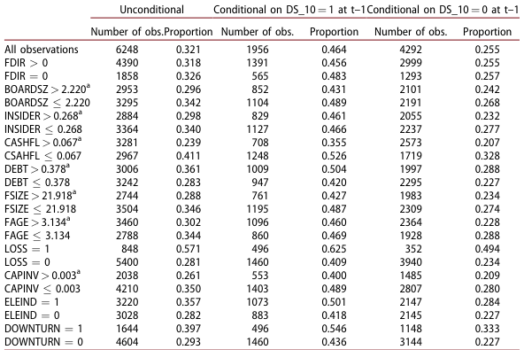

NOTE: complex table shown as an image of the PDF; the text below is a rough machine extraction and may be mis-aligned.

**extracted text (unreliable layout)**

Note: The number of observations is for pooled data of the board terms from 2 to Ni. arepresents that they are the means of the variables for all observations.

THE INTERNATIONAL JOURNAL OF HUMAN RESOURCE MANAGEMENT 2613

Page 18

on their professional traits rather than on the family’s appointment. The result in model (2) of Table 3 indicates that FDIR_NF still has a negative coefficient, and the magnitude of which is much larger than that of FDIR in model (1) (-0.594 vs. 0.323). This implies that non-family female directors, with fewer restrictions coming from the family’s will, are more likely to show women’s leadership styles so as to increase the tendency of retaining employees.

For other explanatory variables, coefficient estimates in all regressions are as expected and most of them are statistically significant. Board size (BOARDSZ) and the proportion of inside directors on the board (INSIDER) are significantly and negatively associated with the tendency of downsizing. As hypothesized, firms are more likely concerned with the interests of shareholders and prone to downsizing when they have a board of smaller size or of more outside directors. CASHFL has negative coefficients, DEBT has positive coefficients, and both are significant. Consistent with our prediction that the firms exposed to more financial constraints (i.e. less cash flow and more debt) tend to make downsizing. The variables for firm size and age (FSIZE and FAGE) have negative

Table 2. Means and Standard Deviations of Variables.

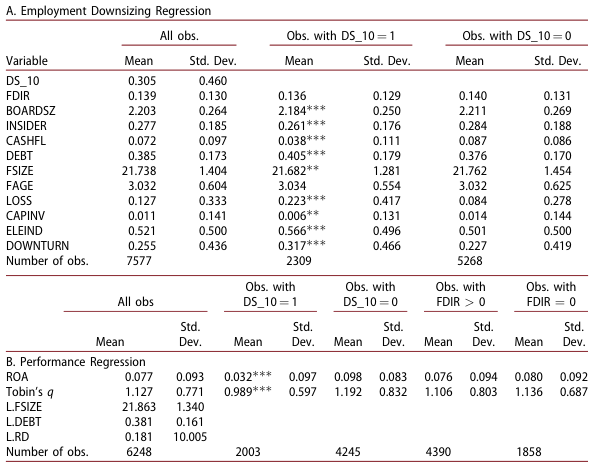

NOTE: complex table shown as an image of the PDF; the text below is a rough machine extraction and may be mis-aligned.

**extracted text (unreliable layout)**

Note: and represents that the difference in means between observations for DS_10 ¼ 1 and observations for DS_10 ¼ 0 is statistically significant at the 0.01 and 0.05 levels, respectively. The difference in the means of performance between observations for FDIR > 0 and observations for FDIR ¼ 0 is not significant.

2614 M.-Y. CHEN AND C.-L. KAO

Page 19

coefficients, but only significant for FAGE. Matured firms are less likely to downsize probably because their long-standing reputation supports them to obtain financial resources to hoard labors. As predicted, the firms experiencing worse earnings (LOSS ¼ 1) or having less capital investment (CAPINV) tend to implement downsizing. ELEIND has positive coefficients, implying that downsizing is more prevalent for the information and electronics firms in Taiwan, as they face significant pressure from severe competition. The positive coefficients of DOWNTURN confirm the relationship between the global economic shocks (internet bubble crash and global financial crisis) and intensive downsizing. Finally, the estimated values of q (its logarithm) are significantly greater than zero, indicating that the disturbances in different two board terms are correlated, so a random-effects probit controlling for unobserved heterogeneity is a necessary specification.

We also examine the impact of female board representation on other types of downsizing. Model (1) of Table 4 presents the result when DS_20, representing that the board implements at least once a more

Table 3. Estimation of Dynamic Probit for Downsizing Strategy (DS_10).

[output not shown]

NOTE: table converted from PDF layout to HTML text; cell boundaries are reconstructed. See PDF if exact alignment matters.

Note: The numbers in parentheses are standard errors. , , and denote significance at the 0.01, 0.05, and 0.1 levels, respectively.

THE INTERNATIONAL JOURNAL OF HUMAN RESOURCE MANAGEMENT 2615

Page 20

striking strategy of more than 20% workforce reductions during its term, is used as the dependent variable of the dynamic probit model. Like the result appeared in the DS_10 regression, FDIR still shows a significantly negative coefficient, indicating that women on boards tend to oppose a larger scale of downsizing.

Next, we distinguish two types of downsizing: reactive and proactive (Love & Nohria, 2005; Mellahi & Wilkinson, 2010). Reactive downsizing is considered as a defensive response to a crisis or a decrease in profitability, largely related to external changes in the marketplace. Proactive downsizing is purposed to enhance competitive advantage by increasing efficiency, upgrading work skills, leveraging new technologies, or restructuring the organization. We identify the DS_10 strategy as a proactive one if the firms concurrently increase their fixed assets (plant, property, and equipment), that is, the average fixed assets for the board term carrying out downsizing are greater than those for the previous board term, and as a reactive one if the firms decrease fixed assets. When firms

Table 4. Estimation of Dynamic Probit for Various Downsizing Strategies.

[output not shown]

NOTE: table converted from PDF layout to HTML text; cell boundaries are reconstructed. See PDF if exact alignment matters.

Note: The numbers in parentheses are standard errors. , , and denote significance at the 0.01, 0.05, and 0.1 levels, respectively.

2616 M.-Y. CHEN AND C.-L. KAO

Page 21

increase fixed assets and at the same time reduce workforce, it is very likely that they are attempting to use increased automation or technological breakthrough to improve efficiency in preparation for expected change in the market conditions. Such downsizing behavior has proactive implication. On the other hand, decreases in fixed assets may involve the closure of underperforming units or production lines. Workforce reductions associated with such divesture are apparently reactive.

Models (2) and (3) show the results when reactive and proactive downsizing indicators are the dependent variable, respectively. FDIR has a significantly negative coefficient in the reactive downsizing regression, but its coefficient is not significant in the proactive downsizing regression. The former has much larger magnitude than the latter (-0.302 vs. 0.089), implying a constructive role of women on boards. Women directors do not have the tendency of halting the proactive downsizing that is necessary for the firms’ efficiency improvement and strategic repositioning. The coefficient of L.DS_10 reveals a positive state dependence only for reactive downsizing. Indeed, because reactive downsizing is generally in response to unfavorable profitability, it is likely to be severe and continue for several rounds of layoffs. Proactive downsizing is characterized as resizing for thriving in the future, so it might be less intense and lack the reasons of conducting continuous downsizing. Finally, for the coefficients of control variables in Table 4, although the statistical significance may differ across models, the coefficients that are significant provide the same implications as those in Table 3.

Table 5 presents the results of GMM estimation for the influence of female directors on firm performance, involving downsizing as the mediating strategy. Models (1)–(4) show the results concerning the accountbased performance (ROA). The Hansen J statistics are not significant in these models, supporting the null hypothesis that the over-identifying restrictions are valid. These models also have insignificant AR(2) statistics at the 5% significance level, indicating no serial correlation among the second differences. Supporting hypothesis 3, the variable FDIR has a significant coefficient 0.261 in model (1), showing a positive gross effect of women on boards on the ROA (path 1 in Figure 1). In model (2), where we deal with the endogeneity of DS_10 by using the predicted value obtained from model (1) of Table 3 as the instrument, DS_10 has a significantly negative coefficient. As predicted by hypothesis 2, downsizing, with 10% reductions as the threshold, is harmful to accountingbased performance (path 3 in Figure 1). Combining this result with the negative effect of FDIR on DS_10 (model (1) of Table 3), we confirm an indirect positive effect of FDIR on the ROA through the mediation of the DS_10 strategy. The coefficient of FDIR in model (2) becomes 0.175,

THE INTERNATIONAL JOURNAL OF HUMAN RESOURCE MANAGEMENT 2617

Page 22

Table 5. System-GMM Estimation of Dynamic Panel Regressions for Women on Boards and Firm Performance—Mediation of Downsizing.

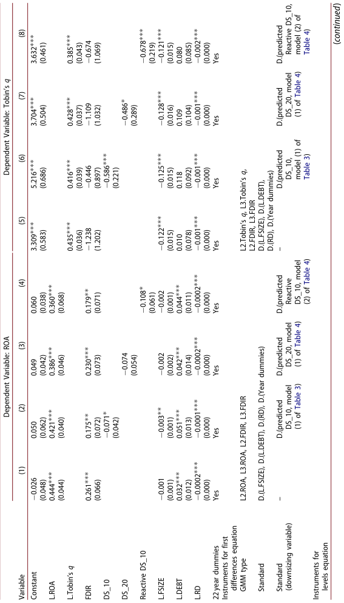

NOTE: complex table shown as an image of the PDF; the text below is a rough machine extraction and may be mis-aligned.

**extracted text (unreliable layout)**

2618 M.-Y. CHEN AND C.-L. KAO

Page 23

Table 5. Continued.

Variable

Dependent Variable: ROA Dependent Variable: Tobin’s q

(1) (2) (3) (4) (5) (6) (7) (8)

GMM type D.L.ROA, D.L.FDIR D.L.Tobin’s q, D.L.FDIR

Standard L.FSIZE, L.DEBT, L.RD, Year dummies L.FSIZE, L.DEBT, L.RD, Year dummies

Standard

(downsizing variable) – predicted

DS_10, model

(1) of Table 3

predicted

DS_20, model

(1) of Table 4

predicted

Reactive DS_10,

model (2) of

Table 4

– predicted

DS_10, model

(1) of Table 3

predicted

DS_20, model

(1) of Table 4

predicted

Reactive DS_10,

model (2) of

Table 4

Hansen J statistic 11.579 10.035 9.313 8.200 14.749 14.634 14.607 12.202 p-value of Hansen J statistic 0.480 0.613 0.676 0.769 0.141 0.146 0.147 0.272 AR(2) statistic 1.943 1.172 1.498 1.205 0.260 0.785 0.514 0.621 p-value of AR(2) statistic 0.052 0.241 0.134 0.228 0.795 0.433 0.607 0.535 Number of firms 1329 1329 1329 1329 1329 1329 1329 1329 Number of observations 6248 6248 6248 6248 6248 6248 6248 6248

Note: The numbers in parentheses are two-step robust standard errors. L. is the lag operator and D. is the backward difference operator. , , and denote significance at the 0.01,

0.05, 0.1 levels, respectively.

THE INTERNATIONAL JOURNAL OF HUMAN RESOURCE MANAGEMENT 2619

Page 24

which means that about 33% of the FDIR’s effect on the ROA, that is, (0.261–0.175)/0.261, has been mediated by the DS_10 downsizing strategy. Hypothesis 4 can thus gain support.

Using the predicted value from model (1) of Table 4 as the instrument, the coefficient of DS_20 (20% reductions as the threshold) in model (3) is also negative but not significant, so the mediating effect of the DS_20 strategy is relatively weak. Next, using the predicted value from model (2) of Table 4 as the instrument, the coefficient of reactive DS_10 is significantly negative. Associated with the negative coefficient of FDIR in model (2) of Table 4, reactive downsizing is shown to have the mediating effect between women on boards and the ROA. Because FDIR is not found to affect the proactive DS_10 strategy in Table (4) (path 2 in Figure 1 has been ruled out), we do not examine the proactive DS_10 strategy in Table 5.

With the same estimation procedures and instruments, models (5)–(8) present the results for the market performance (Tobin’s q). Hansen J and AR(2) tests are all valid for these models. Because all downsizing variables, DS_10, DS_20, and reactive DS_10 appear to have significantly negative coefficients in models (6)–(8), by combining the findings in Tables 3 and 4, we can state that women on boards can exert the positive impact on Tobin’s q indirectly through these downsizing strategies. As described in hypothesis 4, it is important to emphasize that the positive indirect effect of women directors on firm performance, mediated by downsizing, exist for both accounting-based and market performance measures.

FDIR has an insignificantly negative coefficient in model (5). Unlike the ROA, female representation on boards have adverse, although not significant, gross effects on the firm’s Tobin’s q. This finding echoes hypothesis 3 concerning the distinction between accounting and market performance. Female board representation does not positively influence market performance, perhaps because the valuation of a firm in the stock market reflects not only a firm’s ability to generate accounting returns, but also investors’ perceptions and expectations of the firm’s future development. While we find evidence that women on boards can enhance market performance of the firms through their preferences of securing a stable workplace to implement fewer layoffs, such positive indirect effect may be diluted by investors’ general bias against women on boards.

5. Discussion and implications

Whether women on boards can yield higher firm performance, to a certain extent, depends on the socio-cultural context in which board gender

2620 M.-Y. CHEN AND C.-L. KAO

Page 25

diversification occurs. Examining the gross effect of women’s representation on boards, we find support for our contention that the cognitive frames and human capital brought to boards by female directors, particularly non- family female directors, increase the pool of information considered in the decision-making and improve the firm’s accountingbased performance. However, in Taiwanese gender culture where the Confucian philosophy has been perpetuated as the quasi-official ideology up to the present day, investors’ bias against women may lead to unfavorable (although statistically insignificant) market valuation of the firms with female directors. It is likely that our results can be generalized to other Asian countries with social values and corporate culture shaped by Confucianism.

These results also echo the findings of a meta-analysis conducted by Post and Byron (2015). They show that the relationship between women on boards and accounting returns is more positive in countries with stronger shareholder protections, as these protections may motivate boards to make good use of the knowledge, experience, and values that women bring to boards. They also indicate that the relationship between women on boards and market performance is positive in countries with greater gender parity and negative in those with lower gender parity because gender parity facilitates investors’ evaluations of the future earning potential of firms that have more human capital of female directors. Over the past two decades. Taiwan government has devoted itself to strengthening corporate governance and protecting shareholders’ rights. This has gradually encouraged the boards of directors to realize the benefits that women bring to the company, making a strong positive correlation between women on boards and accounting performance. Unfortunately, Taiwanese society still has low gender equality, so investors are reluctant to have a high evaluation to the profitability potential of firms with more women’s human capital.

The implication is that if the government intends to follow the experience of European countries to increase women’s representation on boards by legislative regulation or through a corporate governance evaluation system, how to raise social awareness about gender equality so that the majority of investors can have more understanding about the importance and benefits of diversity and inclusion is a crucial task. Otherwise, in the case that market investors cannot support the value of gender diversity behind the recruitment of female directors, the firms that raise the capital they need from these investors will lack the willingness to move towards the goal of high women’s representation on boards. In this way, the legislation and governance evaluation system will not be able to achieve the desired results.

THE INTERNATIONAL JOURNAL OF HUMAN RESOURCE MANAGEMENT 2621

Page 26

More intriguing results appear when we look into the indirect effect of women on boards on firm performance through the mediation of downsizing. Evidence reveals that because female directors’ leadership style and preferences may bring perspectives that require the board to discuss issues in more depth and to consider a wider variety of stakeholders, the firms with a higher proportion of women on the board of directors tend to implement less downsizing, in particular reactive downsizing, and this talent-retaining strategy constitutes a stable employment policy, which is definitely beneficial to firm performance. Most importantly, although female directors have opposite gross effects on accounting-based and market performance, the positive indirect impact on firm performance is investors’ bias-free, that is, it is reflected on both measures of performance.

This is a noteworthy result because we find an employee-oriented channel (i.e. less downsizing) through which female directors can exercise positive influence on firm performance for both accounting-based and stock market measures. This positive impact of women’s employee-oriented attitude is corresponding to the literature suggesting that women on boards may be a factor in building companies towards more sustainability and producing the benefits of diversity for corporate social performance (e.g. Fernandez- Feijoo et al., 2014; Galbreath, 2011; Shaukat et al., 2016; Zhang et al., 2013). These studies show that because of the difference between female and male directors’ moral and social value systems, board gender diversity is generally associated with greater sustainability reporting, more corporate CSR engagement, and better CSR disclosure and rating. In our study, as downsizing is harmful to firm performance, women directors, who adjust board decisions to less downsizing and more talent retention, may enhance corporate social performance, and resulting better financial performance. Therefore, to increase the benefits of board gender diversity for firm performance, efforts may be directed at giving women directors more decisive power over stakeholder management and improving the status of women in the upper echelon of the firms. As mentioned before, Taiwan is experiencing enormous brain drain to China. Taiwanese government and business have been collaborating in devising or implementing policies to halt this trend. We believe that encouraging firms to recruit more female directors, who facilitate boards’ decisions to view employees in terms of talent assets to be fostered, rather than the costs to be cut for pursuing short-term profit, may be a solution to tackle this issue and eventually will be beneficial to firm performance.

6. Conclusion

This study contributes to the literature on women on boards by showing how female board representation shapes the board’s involvement in the

2622 M.-Y. CHEN AND C.-L. KAO

Page 27

strategy of employment downsizing, which in turn mediates the women directors’ influence on firm performance. The analysis is based on the data of Taiwanese manufacturing firms over 1996–2017. Considerable endogeneity is contained in the econometric model with mediating variables and potential reverse causality, so we mitigate the endogeneity bias by adopting appropriate dynamic models and GMM estimation procedures.

Although gender equality in the workplace has improved in Taiwan in the past two decades, the society is still influenced by the traditional culture, which is often associated with disparaging women. Taiwan also has an economy where fighting the talent drain is an urgent priority for business leaders. Our findings highlight that women directors can be leveraged for higher accounting-based returns and stock market valuation through their less engagement in downsizing. We suggest that government and businesses can make an effort on raising the social consciousness about gender equality, with the expectation that the positive impact of women on boards can be fully reflected on the stock markets. Besides, recruiting more women directors to change the orientation of the decision making towards employees may be a practicable way to deal with brain drain. In our opinion, these policy implications are not specific to Taiwan; they can become a general concern for other countries that confront gender inequality and the brain drain problem.

Given fewer studies examining the relationship between women’s board representation and board strategy involvement, this study proposes a human resource strategy, downsizing, as a theoretically grounded intermediary mechanism that may link two otherwise distal constructs, which are board composition and firm performance. To further explore the relationship between women on boards and firm performance, future research could continue to examine how board composition influences the extent to which boards involve in the strategies that have significant influence on firm performance.

Note

1. The 22 industries are cement, food, plastics, textiles, electrical machinery, electrics and cables, chemicals, biotechnology and medicine, glass and ceramics, paper, iron and steel, rubber, automobiles, optoelectronics, semiconductors, electronic parts and components, computer and peripheral equipment, communications and Internet, electronic product distribution, information services, other electronics, and oil and gas.

Disclosure statement

No potential conflict of interest was reported by the authors.

THE INTERNATIONAL JOURNAL OF HUMAN RESOURCE MANAGEMENT 2623

Page 28

Data availability statement

The data that support the findings of this study are openly available in Taiwan Economic Journal electronic database at https://www.tej.com.tw/.

References

Abe, M. (2002). Corporate governance structure and employment adjustment in Japan:

An empirical analysis using corporate finance data. Industrial Relations: A Journal of Economy and Society, 41(4), 683–702. https://doi.org/10.1111/1468-232X.00269 Adams, R., & Ferreira, D. (2009). Women in the boardroom and their impact on gov-

ernance and performance. Journal of Financial Economics, 94(2), 291–309. https://doi. org/10.1016/j.jfineco.2008.10.007 Adams, R., & Funk, P. (2012). Beyond the glass ceiling: Does gender matter?

Management Science, 58(2), 219–235. https://doi.org/10.1287/mnsc.1110.1452 Adams, R., Licht, A., & Sagiv, L. (2011). Shareholders and stakeholders: How do direc-

tors decide? Strategic Management Journal, 32(12), 1331–1355. https://doi.org/10.1002/ smj.940 Ahmadjian, C. L., & Robinson, P. (2001). Safety in numbers: Downsizing and the

deinstitutionalization of permanent employment in Japan. Administrative Science Quarterly, 46(4), 622–654. https://doi.org/10.2307/3094826 Amabile, T. M., & Conti, R. (1999). Changes in the work environment for creativity

during downsizing. Academy of Management Journal, 42, 630–640. Andreoni, J., & Vesterlund, L. (2001). Which is the fair sex? Gender differences in altru-

ism. The Quarterly Journal of Economics, 116(1), 293–312. https://doi.org/10.1162/ 003355301556419 Babcock, L., Recalde, M. P., Vesterlund, L., & Weingart, L. (2017). Gender differences in

accepting and receiving requests for tasks with low promotability. American Economic Review, 107(3), 714–747. https://doi.org/10.1257/aer.20141734 Baixauli-Soler, J. S., Lucas-Perez, M. E., Martin-Ugedo, J. F., Minguez-Vera, A., &

Sanchez-Marin, G. (2016). Executive directors’ compensation and monitoring: The influence of gender diversity on Spanish boards. Journal of Business Economics and Management, 17(6), 1133–1154. https://doi.org/10.3846/16111699.2014.969767 Bass, B., & Avolio, B. J. (1994). Shatter the glass ceiling: Women may make better man-

agers. Human Resource Management, 33(4), 549–560. https://doi.org/10.1002/hrm. 3930330405 B€aurle, G., Lein, S. M., & Steiner, E. (2018). Employment adjustment and financial con-

straints– Evidence from firm-level data. Working paper, Center of Business and Economics, University of Basel. Benmelech, E., Bergman, N. K., & Seru, A. (2011). Financing Labor. No. w17144,

National Bureau of Economic Research. Bertrand, M., & Mullainathan, S. (2003). Enjoying the quiet life? Corporate governance

and managerial preferences. Journal of Political Economy, 111(5), 1043–1075. https:// doi.org/10.1086/376950 Blundell, R., & Bond, S. (1998). Initial conditions and moment restrictions in dynamic

panel data models. Journal of Econometrics, 87(1), 115–143. https://doi.org/10.1016/ S0304-4076(98)00009-8

2624 M.-Y. CHEN AND C.-L. KAO

Page 29

Bøhren, Ø. Y., & Strøm, R. Ø. (2010). Governance and politics: Regulating independence

and diversity in the board room. Journal of Business Finance & Accounting, 37(9-10), 1281–1308. Boone, A., Field, L., Karpoff, J., & Raheja, C. (2007). The determinants of corporate

board size and composition: An empirical analysis. Journal of Financial Economics, 85(1), 66–101. https://doi.org/10.1016/j.jfineco.2006.05.004 Brauer, M., & Zimmermann, M. (2019). Investor response to workforce downsizing: The

influence of industry waves, macroeconomic outlook, and firm performance. Journal of Management, 45(5), 1775–1801. https://doi.org/10.1177/0149206317734901 Byrnes, J. P., Miller, D. C., & Schafer, W. D. (1999). Gender differences in risk taking: A

meta- analysis. Psychological Bulletin, 125(3), 367–383. https://doi.org/10.1037/0033- 2909.125.3.367 Byron, K., & Post, C. (2016). Women on boards of directors and corporate social per-

formance: A meta-analysis. Corporate Governance: An International Review, 24(4), 428–442. https://doi.org/10.1111/corg.12165 Carpenter, M. A., Geletkanycz, M. A., & Sanders, W. G. (2004). Upper echelons research

revisited: Antecedents, elements, and consequences of top management team composition. Journal of Management, 30(6), 749–778. https://doi.org/10.1016/j.jm.2004.06.001 Carter, D. A., D’Souza, F., Simkins, B. J., & Simpson, W. G. (2010). The gender and eth-

nic diversity of US boards and board committees and firm financial performance. Corporate Governance: An International Review, 18(5), 396–414. https://doi.org/10. 1111/j.1467-8683.2010.00809.x Carter, D. A., Simkins, B. J., & Simpson, W. G. (2003). Corporate governance, board

diversity, and firm value. The Financial Review, 38(1), 33–53. https://doi.org/10.1111/ 1540-6288.00034 Cascio, W. F., & Young, C. E. (2003). Financial consequences of employment-change

decisions in major US corporations, 1982-2000. In De Meuse, K. P. & Marks, L. (Eds.). Resizing the Organization: Managing Layoffs, Divestitures and Closings. : 131–156. Jossey Bass. Cascio, W. F., Young, C. E., & Morris, J. R. (1997). Financial consequences of employ-

ment-change decisions in major US corporations. Academy of Management Journal, 40(5), 1175–1189. Christiansen, L., Lin, H., Pereira, J., Topalova, P. B., & Turk-Ariss, R. (2016). Gender

diversity in senior positions and firm performance: Evidence from Europe. IMF working paper. https://doi.org/10.5089/9781513553283.001 Chuma, A. H. (2002). Employment adjustments in Japanese firms during the current

crisis. Industrial Relations: A Journal of Economy and Society, 41(4), 653–682. https:// doi.org/10.1111/1468-232X.00268 Datta, D. K., Guthrie, J. P., Basuil, D., & Pandey, A. (2010). Causes and effects of

employee downsizing: A review and synthesis. Journal of Management, 36(1), 281–348. https://doi.org/10.1177/0149206309346735 Davis, P. S., Babakus, E., Englis, P. D., & Pett, T. (2010). The influence of CEO gender

on market orientation and performance in service small and medium-sized service businesses. Journal of Small Business Management, 48(4), 475–496. https://doi.org/10. 1111/j.1540-627X.2010.00305.x De Meuse, K. P., & Dai, G. (2012). Reducing costs and enhancing efficiency or damag-

ing the company: Downsizing in today’s global economy. In Quick, J. C., Cooper, G. L., & Pandey, A. (Eds.). Downsizing–Is Less Still More?, 258–290. Cambridge University Press.

THE INTERNATIONAL JOURNAL OF HUMAN RESOURCE MANAGEMENT 2625

Page 30

De Meuse, K. P., Vanderheiden, P. A., & Bergmann, T. J. (1994). Announced lay-offs:

Their effect on corporate financial performance. Human Resource Management, 33(4), 509–530. https://doi.org/10.1002/hrm.3930330403 Dezs€o, C., & Ross, D. (2012). Does female representation in top management improve

firm performance? A panel data investigation. Strategic Management Journal, 33(9), 1072–1089. https://doi.org/10.1002/smj.1955 Erhardt, N. L., Werbel, J. D., & Shrader, C. B. (2003). Board of director diversity and

firm financial performance. Corporate Governance, 11(2), 102–111. https://doi.org/10. 1111/1467-8683.00011 Fama, E. F., & Jensen, M. C. (1983). Separation of ownership and control. The Journal

of Law and Economics, 26(2), 301–325. https://doi.org/10.1086/467037 Farrell, K. A., & Hersch, P. L. (2005). Additions to corporate boards: The effect of gen-

der. Journal of Corporate Finance, 11(1-2), 85–106. https://doi.org/10.1016/j.jcorpfin. 2003.12.001 Fernandez-Feijoo, B., Romero, S., & Ruiz-Blanco, S. (2014). Women on boards: Do they

affect sustainability reporting? Corporate Social Responsibility and Environmental Management, 21(6), 351–364. Francoeur, C., Labelle, R., & Sinclair-Desgagne, B. (2008). Gender diversity in corporate

governance and top management. Journal of Business Ethics, 81(1), 83–95. https://doi. org/10.1007/s10551-007-9482-5 Galbreath, J. (2011). Are there gender-related influences on corporate sustainability? A

study of women on boards of directors. Journal of Management & Organization, 17, 17–38. Guthrie, J. P., & Datta, D. K. (2008). Dumb and dumber: The impact of downsizing on

firm performance as moderated by industry conditions. Organization Science, 19(1), 108–123. https://doi.org/10.1287/orsc.1070.0298 Hambrick, D. (2007). Upper echelons theory: An update. Academy of Management

Review, 32(2), 334–343. https://doi.org/10.5465/amr.2007.24345254 Hambrick, D. C., & Mason, P. A. (1984). Upper echelons: The organization as a reflec-

tion of its top managers. Academy of Management Review, 9(2), 193–206. https://doi. org/10.5465/amr.1984.4277628 Hamermesh, D. S., & Pfann, G. A. (1996). Adjustment costs in factor demand. Journal

of Economic Literature, 34(3), 1264–1292. Heckman, J. J. (1981). The incidental parameters problem and the problem of initial

conditions in estimating a discrete time–discrete data stochastic process. In, Manski C. F. & McFadden, D. (Eds.). Structural Analysis of Discrete Data with Econometric Applications. MIT Press. Hillman, A. J., & Dalziel, T. (2003). Boards of directors and firm performance:

Integrating agency and resource dependence perspectives. Academy of Management Review, 28(3), 383–396. https://doi.org/10.5465/amr.2003.10196729 Hillman, A. J., Cannella, A. A., & Paetzold, R. L. (2000). The resource dependence role

of corporate directors: Strategic adaptation of board composition in response to environmental change. Journal of Management Studies, 37(2), 235–256. https://doi.org/10. 1111/1467-6486.00179 Hyslop, D. R. (1999). State dependence, serial correlation and heterogeneity in intertem-

poral labor force participation of married women. Econometrica, 67(6), 1255–1294. https://doi.org/10.1111/1468-0262.00080 Jensen, M. C. (1986). Agency costs of free cash flow, corporate finance, and takeovers.

The American Economic Review, 76(2), 323–329.

2626 M.-Y. CHEN AND C.-L. KAO

Page 31

Jensen, M. C., & Meckling, W. H. (1976). Theory of the firm: Managerial behaviour,

agency costs and structure. Journal of Financial Economics, 3(4), 305–360. https://doi. org/10.1016/0304-405X(76)90026-X Johnson, S. G., Schnatterly, K., & Hill, A. D. (2013). Board composition beyond inde-

pendence: Social capital, human capital, and demographics. Journal of Management, 39(1), 232–262. https://doi.org/10.1177/0149206312463938 Kawai, N. (2015). Does downsizing really matter? Evidence from Japanese multinationals

in the European manufacturing industry. The International Journal of Human Resource Management, 26(4), 501–519. https://doi.org/10.1080/09585192.2011.616525 Khan, W. A., & Vieito, J. P. (2013). CEO gender and firm performance. Journal of

Economics and Business, 67, 55–66. https://doi.org/10.1016/j.jeconbus.2013.01.003 Krishnan, H. A., & Park, D. (2005). A few good women: On top management teams.

Journal of Business Research, 58(12), 1712–1720. https://doi.org/10.1016/j.jbusres.2004. 09.003 Levi, M., Li, K., & Zhang, F. (2014). Director gender and mergers and acquisitions.

Journal of Corporate Finance, 28, 185–200. https://doi.org/10.1016/j.jcorpfin.2013.11. 005 Linck, J. S., Netter, J. M., & Yang, T. (2008). The determinants of board structure.

Journal of Financial Economics, 87(2), 308–328. https://doi.org/10.1016/j.jfineco.2007. 03.004 Lopez Bohle, S. A., Chambel, M. J., & Diaz-Valdes Iriarte, A. (2018). Job insecurity, pro-

cedural justice and downsizing survivor affects. The International Journal of Human Resource Management, . https://doi.org/10.1080/09585192.2018.1482939 Love, E. G., & Nohria, N. (2005). Reducing slack: The performance consequences of

downsizing by large industrial firms, 1977–93. Strategic Management Journal, 26(12), 1087–1108. https://doi.org/10.1002/smj.487 Lowe, K. B. (1998). Downsizing and firm performance: Panacea or paradise lost?

Academy of Management Perspectives, 12(4), 130–131. https://doi.org/10.5465/ame. 1998.1334017 Luan, C. J., Tien, C., & Chi, Y. C. (2013). Downsizing to the wrong size? A study of the

impact of downsizing on firm performance during an economic downturn. The International Journal of Human Resource Management, 24(7), 1519–1535. https://doi. org/10.1080/09585192.2012.725073 Lucas-Perez, M. E., Mınguez-Vera, A., Baixauli-Soler, J. S., Martın-Ugedo, J. F., &

Sanchez-Marın, G. (2015). Women on the board and managers’ pay: Evidence from Spain. Journal of Business Ethics, 129(2), 265–280. https://doi.org/10.1007/s10551-014- 2148-1 L€uckerath-Rovers, M. (2013). Women on boards and firm performance. Journal of

Management & Governance, 17(2), 491–509. Matsa, D. A., & Miller, A. R. (2013). A female style in corporate leadership? Evidence

from quotas. American Economic Journal: Applied Economics, 5(3), 136–169. Matsa, D. A., & Miller, A. R. (2014). Workforce reductions at women-owned businesses

in the United States. Ilr Review, 67(2), 422–452. https://doi.org/10.1177/ 001979391406700206 Matsumoto, A., Hara, H., & Nawata, K. (2011). An analysis of the employment adjust-

ment behavior of Japanese firms in the 1990s using financial data. Working paper, University of Tokyo. McMahan, G. C., Pandey, A., & Martinson, B. (2012). To downsize human capital: A

strategic human resource perspective on the disparate outcomes of downsizing. In

THE INTERNATIONAL JOURNAL OF HUMAN RESOURCE MANAGEMENT 2627

Page 32

Quick, J. C., Cooper, G. L., & Pandey, A. (Eds.). Downsizing–Is Less Still More?. : 134–167. Cambridge University Press. Mellahi, K., & Wilkinson, A. (2010). A study of the association between level of slack

reduction following downsizing and innovation output. Journal of Management Studies, 47(3), 483–508. https://doi.org/10.1111/j.1467-6486.2009.00872.x Mınguez-Vera, A., & Martin, A. (2011). Gender and management on Spanish SMEs: An

empirical analysis. The International Journal of Human Resource Management, 22(14), 2852–2873. https://doi.org/10.1080/09585192.2011.599948 Morrison, E. W., & Robinson, S. L. (1997). When employees feel betrayed: A model of

how psychological contract violation develops. Academy of Management Review, 22(1), 226–256. https://doi.org/10.5465/amr.1997.9707180265 Mu~noz-Bullon, F., & Sanchez-Bueno, M. J. (2010). Downsizing implementation and

financial performance. Management Decision, 48(8), 1181–1197. Niederle, M., & Vesterlund, L. (2007). Do women shy away from competition? Do men

compete too much? The Quarterly Journal of Economics, 122(3), 1067–1101. https:// doi.org/10.1162/qjec.122.3.1067 Oi, W. Y. (1962). Labor as a quasi-fixed factor. Journal of Political Economy, 70(6),

538–555. https://doi.org/10.1086/258715 Parsons, D. O. (1972). Specific human capital: An application to quit rates and layoff

rates. Journal of Political Economy, 80(6), 1120–1143. https://doi.org/10.1086/259961 Pfeffer, J., & Salancik, G. (1978). The External Control of Organizations: A Resource-

Dependence Perspective. Harper and Row. Post, C., & Byron, K. (2015). Women on boards and firm financial performance: A

meta- analysis. Academy of Management Journal, 58(5), 1546–1571. https://doi.org/10. 5465/amj.2013.0319 Pye, A., & Pettigrew, A. (2005). Studying board context, process and dynamics: Some

challenges for the future. British Journal of Management, 16(s1), S27–S38. https://doi. org/10.1111/j.1467-8551.2005.00445.x Rao, K., & Tilt, C. (2016). Board composition and corporate social responsibility: The

role of diversity, gender, strategy and decision making. Journal of Business Ethics, 138(2), 327–347. https://doi.org/10.1007/s10551-015-2613-5 Rose, C. (2007). Does female board representation influence firm performance? The

Danish evidence. Corporate Governance: An International Review, 15(2), 404–413. https://doi.org/10.1111/j.1467-8683.2007.00570.x Rousseau, D. (1995). Psychological Contracts in Organizations: Understanding Written

and Unwritten Agreements. Sage Publications. Shah, P. P. (2000). Network destruction: The structural implications of downsizing.

Academy of Management Journal, 43, 101–112. Sharpe, S. A. (1994). Financial market imperfections, firm leverage, and the cyclicality of

employment. American Economic Review, 84(4), 1060–1074. Shaukat, A., Qiu, Y., & Trojanowski, G. (2016). Board attributes, corporate social

responsibility strategy, and corporate environmental and social performance. Journal of Business Ethics, 135(3), 569–585. https://doi.org/10.1007/s10551-014-2460-9 Stewart, M. B. (2007). The interrelated dynamics of unemployment and low-wage

employment. Journal of Applied Econometrics, 22(3), 511–531. https://doi.org/10.1002/ jae.922 Vicente-Lorente, J. D., & Suarez-Gonzalez, I. (2007). Ownership traits and downsizing

behaviour: Evidence for the largest Spanish firms, 1990—1998. Organization Studies, 28(11), 1613–1638. https://doi.org/10.1177/0170840607076591

2628 M.-Y. CHEN AND C.-L. KAO

Page 33

Wagar, T. H. (2009). Factors affecting permanent workforce reduction: Evidence from

large Canadian organizations. Canadian Journal of Administrative Sciences / Revue Canadienne Des Sciences de L’administration, 14(3), 303–314. https://doi.org/10.1111/j. 1936-4490.1997.tb00137.x Wang, Y. H. (2020). Does board gender diversity bring better financial and governance

performances? An empirical investigation of cases in Taiwan. Sustainability, 12(8), 3205. https://doi.org/10.3390/su12083205 Yawson, A. (2006). Evaluating the characteristics of corporate boards associated with

layoff decisions. Corporate Governance: An International Review, 14(2), 75–84. https:// doi.org/10.1111/j.1467-8683.2006.00488.x Zhang, J. Q., Zhu, H., & Ding, H. B. (2013). Board composition and corporate social

responsibility: An empirical investigation in the post Sarbanes-Oxley era. Journal of Business Ethics, 114(3), 381–392. https://doi.org/10.1007/s10551-012-1352-0 Zhang, Y., & Qu, H. (2016). The impact of CEO succession with gender change on firm

performance and successor early departure: Evidence from China’s publicly listed companies in 1997–2010. Academy of Management Journal, 59(5), 1845–1868. https:// doi.org/10.5465/amj.2014.0176

THE INTERNATIONAL JOURNAL OF HUMAN RESOURCE MANAGEMENT 2629

Page 34